# ggplot2_chapter2

Nade Kang

July 6, 2018

# Solution Manual for ggplot2 Elegant Graphics for Data Analysis by Hadley Wickham

# ggplot2 Chpater 2 Getting Started with ggplot2

## *Exercise 2.2.1*

### Load Packages

```r
library(tidyverse)
```

*Question 1* List five functions that you could use to get more information about the mpg dataset.

```r
View(mpg)
head(mpg)
tail(mpg)
dim(mpg)
names(mpg)
```

*Question 2* How can you find out what other datasets are included with ggplot2?

```r
data(package = "ggplot2")
```

*Question 3* Apart from the US, most countries use fuel consumption (fuel consumed over fixed distance) rather than fuel economy (distance travelled with fixed amount of fuel). How could you convert cty and hwy into the European standard of l/100km?

```r
head(mpg)
```

```
## # A tibble: 6 x 11
##   manufacturer model displ  year   cyl trans drv     cty   hwy fl    class
##   <chr>        <chr> <dbl> <int> <int> <chr> <chr> <int> <int> <chr> <chr>
## 1 audi         a4      1.8  1999     4 auto~ f        18    29 p     comp~
## 2 audi         a4      1.8  1999     4 manu~ f        21    29 p     comp~
## 3 audi         a4      2    2008     4 manu~ f        20    31 p     comp~
## 4 audi         a4      2    2008     4 auto~ f        21    30 p     comp~
## 5 audi         a4      2.8  1999     6 auto~ f        16    26 p     comp~
## 6 audi         a4      2.8  1999     6 manu~ f        18    26 p     comp~
```

```r
mpg_km <- mpg %>%
  mutate(cty_l100km = cty * 235.215,
         hwy_l100lm = hwy * 235.215)
mpg_km %>% select(cty:hwy_l100lm)
```

```
## # A tibble: 234 x 6
##      cty   hwy fl    class   cty_l100km hwy_l100lm
##    <int> <int> <chr> <chr>        <dbl>      <dbl>
##  1    18    29 p     compact      4234.      6821.
##  2    21    29 p     compact      4940.      6821.
##  3    20    31 p     compact      4704.      7292.
##  4    21    30 p     compact      4940.      7056.
##  5    16    26 p     compact      3763.      6116.
##  6    18    26 p     compact      4234.      6116.
##  7    18    27 p     compact      4234.      6351.
##  8    18    26 p     compact      4234.      6116.
##  9    16    25 p     compact      3763.      5880.
## 10    20    28 p     compact      4704.      6586.
## # ... with 224 more rows
```

*Question 4* Which manufacturer has the most the models in this dataset?Which model has the most variations? Does your answer change if you remove the redundant specification of drive train (e.g. “pathfinder 4wd”, “a4 quattro”) from the model name?

Manufacturer with the most models

```r
mpg %>%
  group_by(manufacturer) %>%
  summarise(n = n()) %>%
  arrange(desc(n))
```

```
## # A tibble: 15 x 2
##    manufacturer     n
##    <chr>        <int>
##  1 dodge           37
##  2 toyota          34
##  3 volkswagen      27
##  4 ford            25
##  5 chevrolet       19
##  6 audi            18
##  7 hyundai         14
##  8 subaru          14
##  9 nissan          13
## 10 honda            9
## 11 jeep             8
## 12 pontiac          5
## 13 land rover       4
## 14 mercury          4
## 15 lincoln          3
```

As you can see, Dodge has the most models, a number of 37.

The model that has the most variations :

```r
unique(mpg$model)
```

```
##  [1] "a4"                     "a4 quattro"
##  [3] "a6 quattro"             "c1500 suburban 2wd"
##  [5] "corvette"               "k1500 tahoe 4wd"
##  [7] "malibu"                 "caravan 2wd"
##  [9] "dakota pickup 4wd"      "durango 4wd"
## [11] "ram 1500 pickup 4wd"    "expedition 2wd"
## [13] "explorer 4wd"           "f150 pickup 4wd"
## [15] "mustang"                "civic"
## [17] "sonata"                 "tiburon"
## [19] "grand cherokee 4wd"     "range rover"
## [21] "navigator 2wd"          "mountaineer 4wd"
## [23] "altima"                 "maxima"
## [25] "pathfinder 4wd"         "grand prix"
## [27] "forester awd"           "impreza awd"
## [29] "4runner 4wd"            "camry"
## [31] "camry solara"           "corolla"
## [33] "land cruiser wagon 4wd" "toyota tacoma 4wd"
## [35] "gti"                    "jetta"
## [37] "new beetle"             "passat"
```

```r
library(stringr)
str_trim(str_replace_all(unique(mpg$model), c("quattro" = "", "4wd" = "",
                                              "2wd" = "", "awd" = "")))
```

```
##  [1] "a4"                 "a4"                 "a6"
##  [4] "c1500 suburban"     "corvette"           "k1500 tahoe"
##  [7] "malibu"             "caravan"            "dakota pickup"
## [10] "durango"            "ram 1500 pickup"    "expedition"
## [13] "explorer"           "f150 pickup"        "mustang"
## [16] "civic"              "sonata"             "tiburon"
## [19] "grand cherokee"     "range rover"        "navigator"
## [22] "mountaineer"        "altima"             "maxima"
## [25] "pathfinder"         "grand prix"         "forester"
## [28] "impreza"            "4runner"            "camry"
## [31] "camry solara"       "corolla"            "land cruiser wagon"
## [34] "toyota tacoma"      "gti"                "jetta"
## [37] "new beetle"         "passat"
```

## *Exercise 2.3.1*

*Question 1* How would you describe the relationship between cty and hwy? Do you have any concerns about drawing conclusions from that plot? To understand the relationship, we need to make a plot:

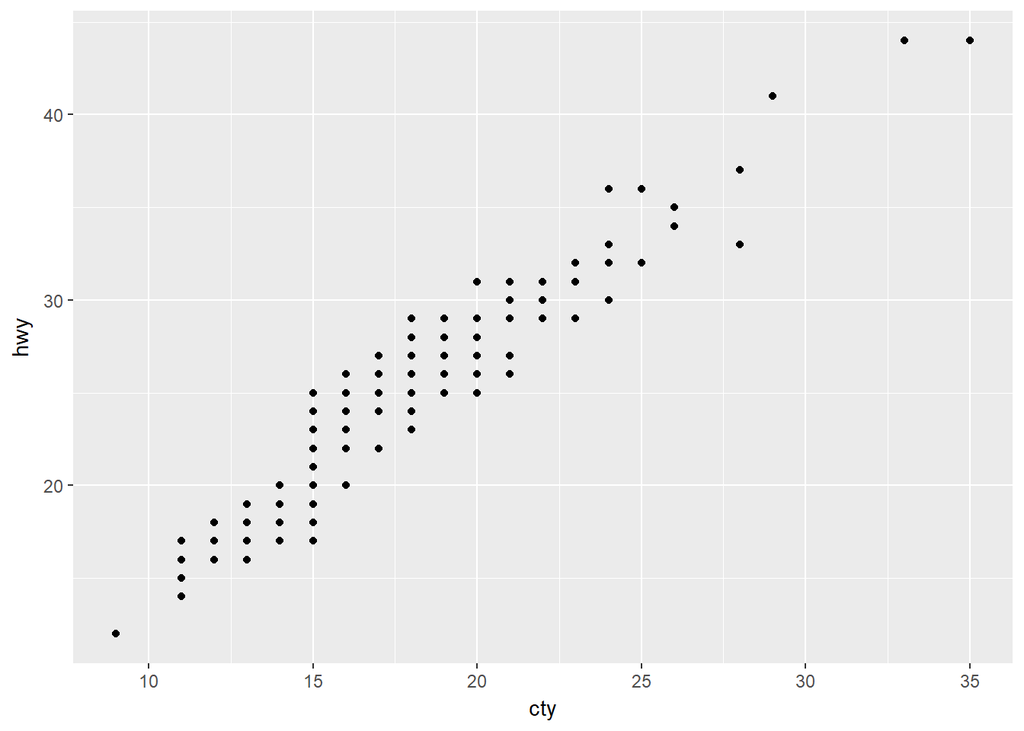

```r
ggplot(mpg, aes(x = cty, y = hwy)) +
  geom_point()
```

It appears that there is a positive linear relationship between cty and hwy.

*Question 2* What does ggplot(mpg, aes(model, manufacturer)) + geom point() show? Is it useful? How could you modify the data to make it more informative?

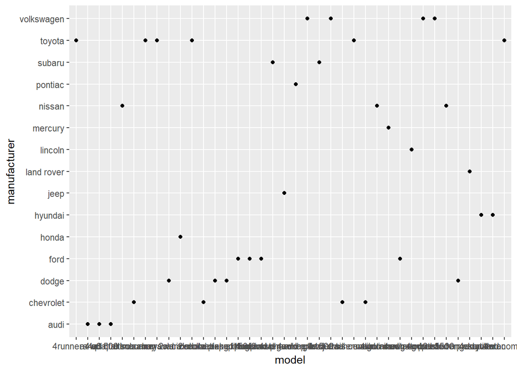

```r
ggplot(mpg, aes(model, manufacturer)) +
  geom_point()
```

This plot has problems. First, the x-axis names in model are too long, that the plot doesn’t show all the full names. This makes it impossible for people to understand. Second, this plot doesn’t really help people understand the relationship between model and manufacturer for the manufacturer may have several models such as e.g. audi and camry.

A better approach is to check a manufacturer+model combination count

```r
df <- mpg %>%
  mutate(manuModel = paste(manufacturer, model, sep = " "))

df  %>%
  select(manufacturer, model, manuModel)
```

```
## # A tibble: 234 x 3
##    manufacturer model      manuModel
##    <chr>        <chr>      <chr>
##  1 audi         a4         audi a4
##  2 audi         a4         audi a4
##  3 audi         a4         audi a4
##  4 audi         a4         audi a4
##  5 audi         a4         audi a4
##  6 audi         a4         audi a4
##  7 audi         a4         audi a4
##  8 audi         a4 quattro audi a4 quattro
##  9 audi         a4 quattro audi a4 quattro
## 10 audi         a4 quattro audi a4 quattro
## # ... with 224 more rows
```

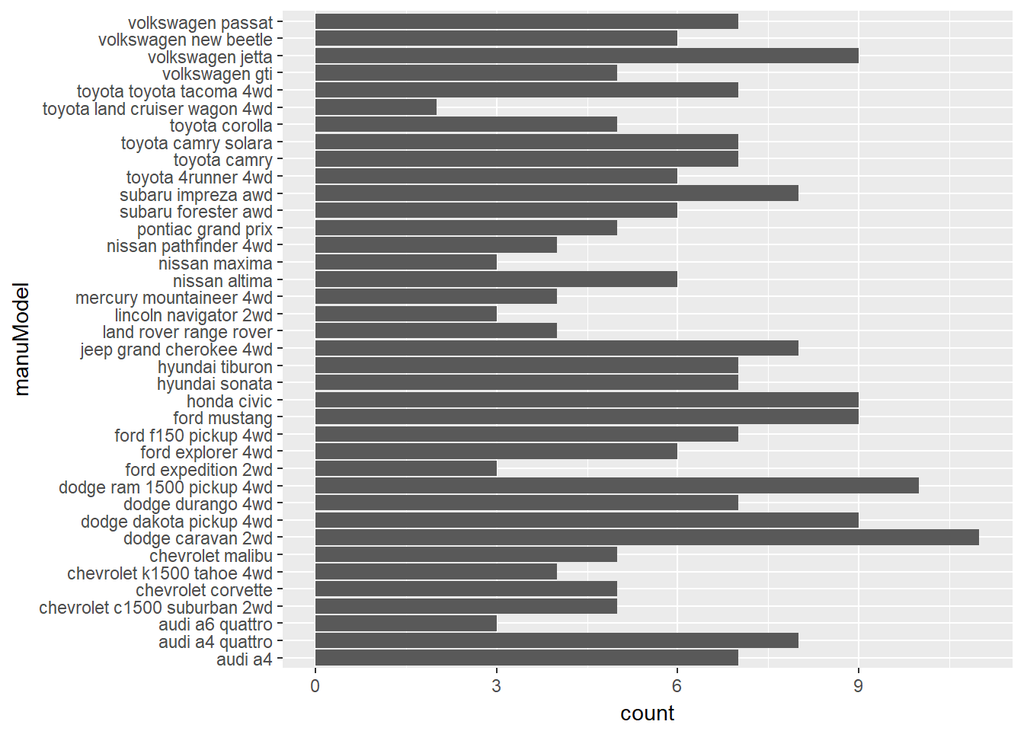

```r
ggplot(df, aes(x = manuModel)) +
  geom_bar() +
  coord_flip()
```

*Question 3* Describe the data, aesthetic mappings and layers used for each of the following plots. You’ll need to guess a little because you haven’t seen all the datasets and functions yet, but use your common sense! See if you can predict what the plot will look like before running the code.

1. ggplot(mpg, aes(cty, hwy)) + geom point()
2. ggplot(diamonds, aes(carat, price)) + geom point()
3. ggplot(economics, aes(date, unemploy)) + geom line()
4. ggplot(mpg, aes(cty)) + geom histogram()

```r
summary(ggplot(mpg, aes(cty, hwy)) + geom_point())
```

```
## data: manufacturer, model, displ, year, cyl, trans, drv, cty, hwy,
##   fl, class [234x11]
## mapping:  x = cty, y = hwy
## faceting: <ggproto object: Class FacetNull, Facet>
##     compute_layout: function
##     draw_back: function
##     draw_front: function
##     draw_labels: function
##     draw_panels: function
##     finish_data: function
##     init_scales: function
##     map: function
##     map_data: function
##     params: list
##     render_back: function
##     render_front: function
##     render_panels: function
##     setup_data: function
##     setup_params: function
##     shrink: TRUE
##     train: function
##     train_positions: function
##     train_scales: function
##     vars: function
##     super:  <ggproto object: Class FacetNull, Facet>
## -----------------------------------
## geom_point: na.rm = FALSE
## stat_identity: na.rm = FALSE
## position_identity
```

As you can see, we can use summary() function to get full details about a chunk of plot codes. But in general, the codes above has one dataset, mapping to two variables in that data set, and has one layer of plots.

## *Exercises 2.4.1*

*Question 1* Experiment with the colour, shape and size aesthetics. What happens when you map them to continuous values? What about categorical values? What happens when you use more than one aesthetic in a plot? Using mpg dataset as an example, first I map color, shape, and size to continuous variables:

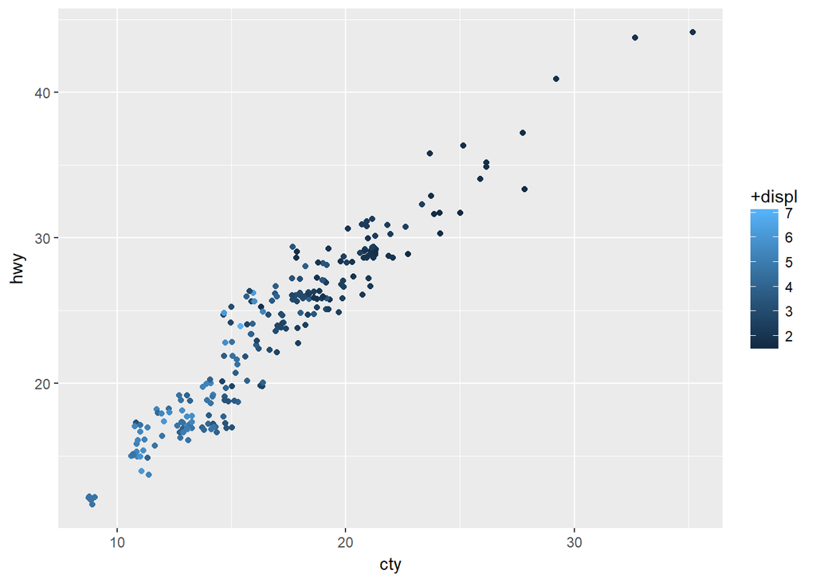

```r
ggplot(mpg, aes(cty, hwy, color = +displ)) +
  geom_jitter()
```

What you get is a color scale, which you can use +/- sign to change the direction of color scale.

But the problem is that, color and size might work with continuous variables, but shape doesn’t. Because the various numbers could deplete the current availble shapes that represent them.

```r
ggplot(mpg, aes(cty, hwy, shape = displ)) +
  geom_point()

# You get:
# Error: A continuous variable can not be mapped to shape
```

You can use more than one aesthetic in a plot, such as:

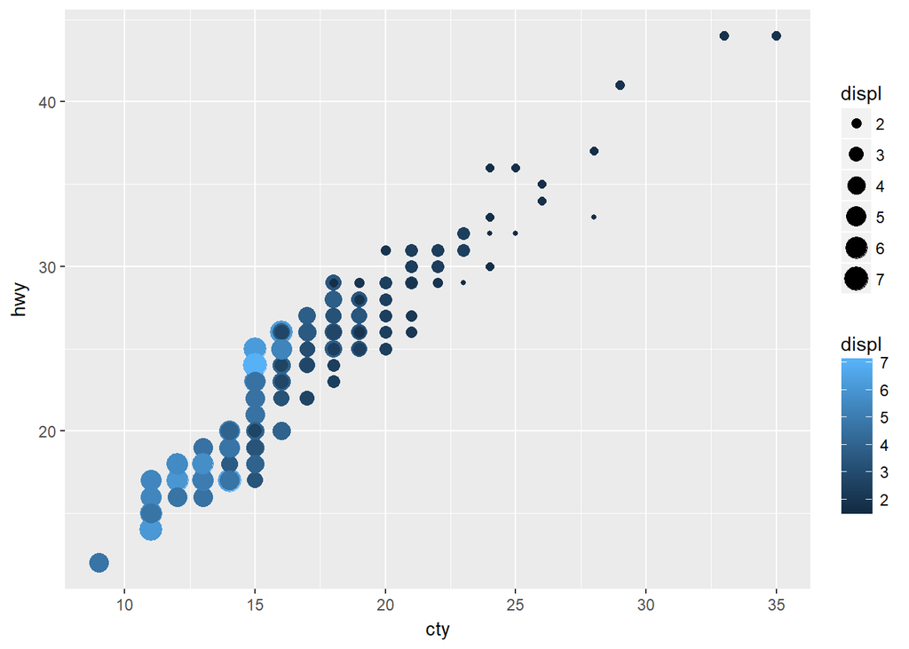

```r
ggplot(mpg, aes(cty, hwy, size = displ, color = displ)) +
  geom_point()
```

*Question 2* What happens if you map a continuous variable to shape? Why? What happens if you map trans to shape? Why? The first part has been answered in the previous question. The second part to map trans to shape:

```
## Warning: The shape palette can deal with a maximum of 6 discrete values
## because more than 6 becomes difficult to discriminate; you have
## 10. Consider specifying shapes manually if you must have them.
```

```
## Warning: Removed 96 rows containing missing values (geom_point).
```

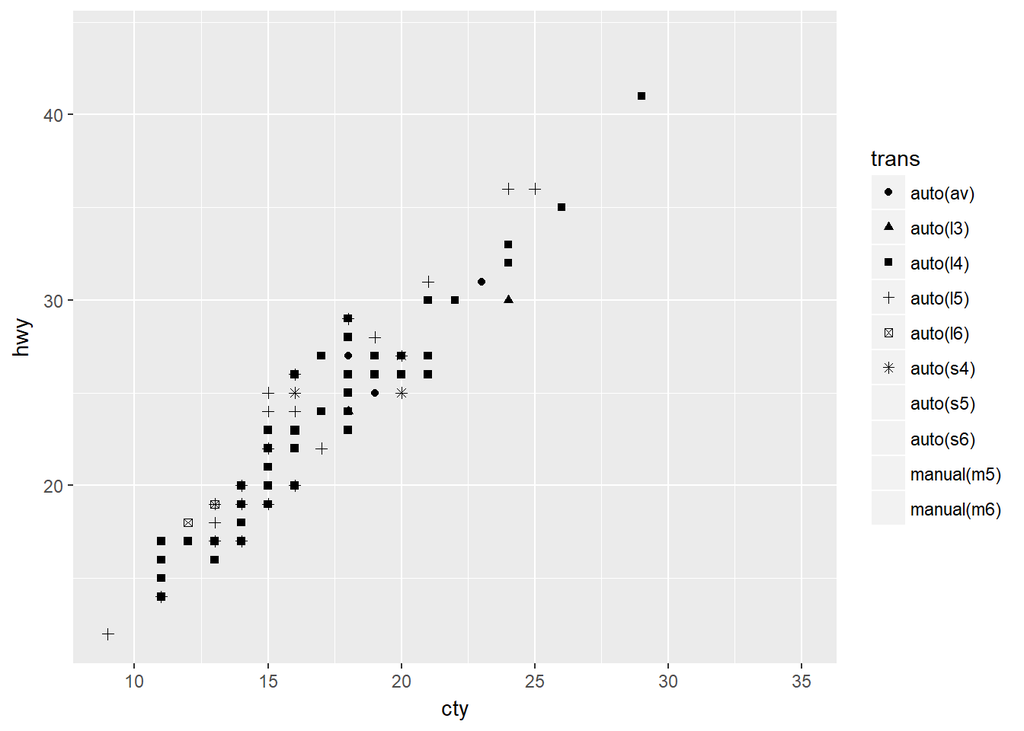

```r
ggplot(mpg, aes(cty, hwy, shape = trans)) +
  geom_point()
```

The plot generates a warning that shape for more than 6 discrete values becomes hard to discriminate.

*Question 3* How is drive train related to fuel economy? How is drive train related to engine size and class?

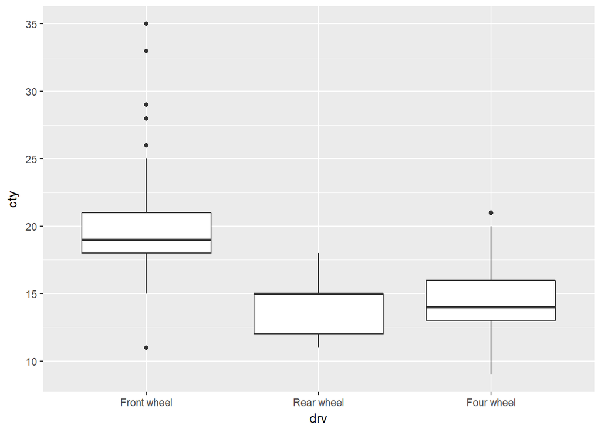

```r
ggplot(mpg, aes(drv, cty)) +
  geom_boxplot() +
  scale_x_discrete(labels = c("Front wheel", "Rear wheel", "Four wheel"),
                   limits = c("f", "r", "4"))
```

For drive train, engine size, and class, we need to reorder the class based on engine size first with median, and then plot class on x-axis and engine size on y-axis, with drive train as color.

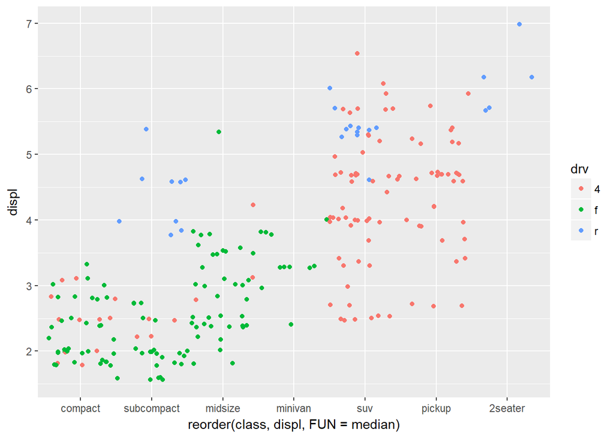

```r
ggplot(mpg, aes(reorder(class, displ, FUN = median), displ, color = drv)) +
  geom_jitter(width = 0.5)
```

## Exercises 2.5.1

*Question 1* What happens if you try to facet by a continuous variable like hwy? What about cyl? What’s the key difference?

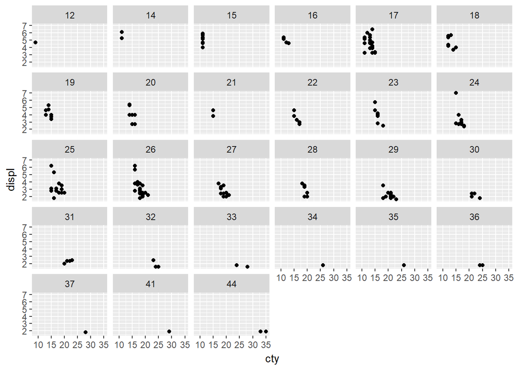

```r
ggplot(mpg, aes(x = cty, y = displ)) +
  geom_point() +
  facet_wrap(~ hwy)
```

When you run facet_wrap(~continuous) with continuous variable, the whole plot becomes hard to grasp because there are too many graphs.

Then we try to run the same thing with cyl:

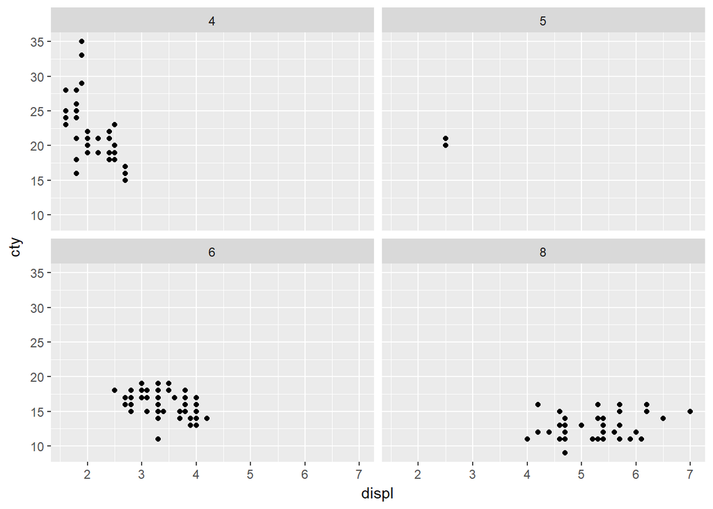

```r
ggplot(mpg, aes(displ, cty)) +
  geom_point() +
  facet_wrap(~ cyl)
```

With cyl, which only has four different values, this picture is much easier to read. The key difference is that hwy has way too many variation in values than cyl does.

*Question 2* Use facetting to explore the three-way relationship between fuel economy, engine size, and number of cylinders. How does facetting by number of cylinders change your assessment of the relationship between engine size and fuel economy?

The pattern can be seen in the last plot.

*Question 3* Read the documentation for facet wrap(). What arguments can you use to control how many rows and columns appear in the output?

```r
?facet_wrap
```

```
## starting httpd help server ... done
```

We can use nrow and ncol to control the rows and columns that appear in the output.

*Question 4* What does the scales argument to facet wrap() do? When might you use it?

should Scales be fixed (“fixed”, the default), free (“free”), or free in one dimension (“free_x”, “free_y”).

```r
library(mgcv)
library(MASS)
```

## Exercises 2.6.6

*Question 1* What’s the problem with the plot created by ggplot(mpg, aes(cty, hwy)) + geom point()? Which of the geoms described above is most effective at remedying the problem?

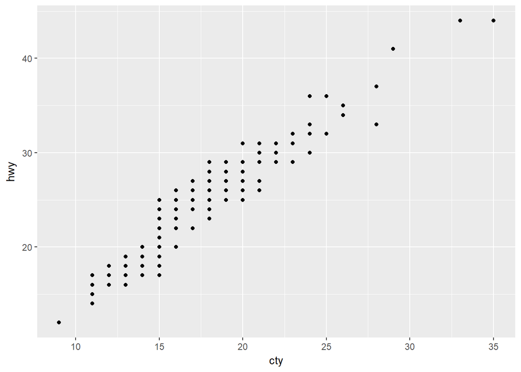

```r
ggplot(mpg, aes(cty, hwy)) +
  geom_point()
```

The problem with this plot is that, there is overplotting, so that this graph doesn’t show all the availble data points in the dataset.

The solution to this problem is to use geom_jitter().

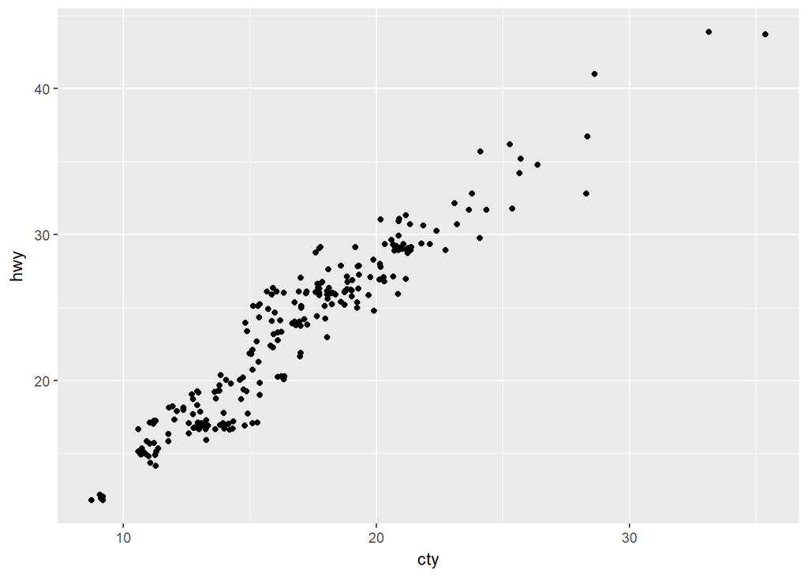

```r
ggplot(mpg, aes(cty, hwy)) +
  geom_jitter()
```

*Question 2* One challenge with ggplot(mpg, aes(class, hwy)) + geom boxplot() is that the ordering of class is alphabetical, which is not terribly useful. How could you change the factor levels to be more informative? Rather than reordering the factor by hand, you can do it automatically based on the data: ggplot(mpg, aes(reorder(class, hwy), hwy)) + geom boxplot(). What does reorder() do? Read the documentation.

You can check reorder() using:

```r
?reorder
```

reorder is a generic function. The “default” method treats its first argument as a categorical variable, and reorders its levels based on the values of a second variable, usually numeric.

*Question 3* Explore the distribution of the carat variable in the diamonds dataset. What binwidth reveals the most interesting patterns?

We can generate several plots with different binwidth:

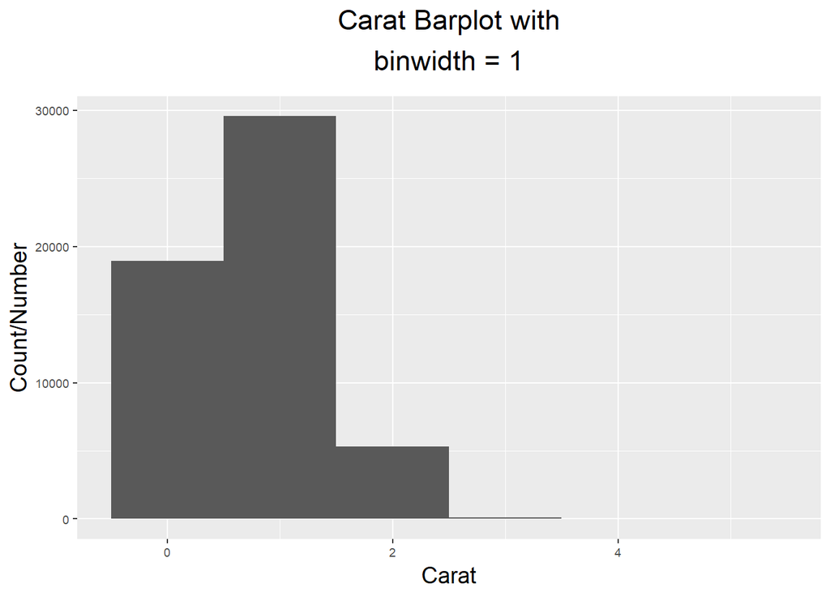

```r
ggplot(diamonds, aes(carat)) +
  geom_bar(binwidth = 1) +
  ggtitle(expression(atop("Carat Barplot with", "binwidth = 1"))) +
  xlab("Carat") +
  ylab("Count/Number") +
  theme(plot.title = element_text(hjust = 0.5), title = element_text(size = 14),
        text = element_text(size = 9))
```

As we change the binwidth:

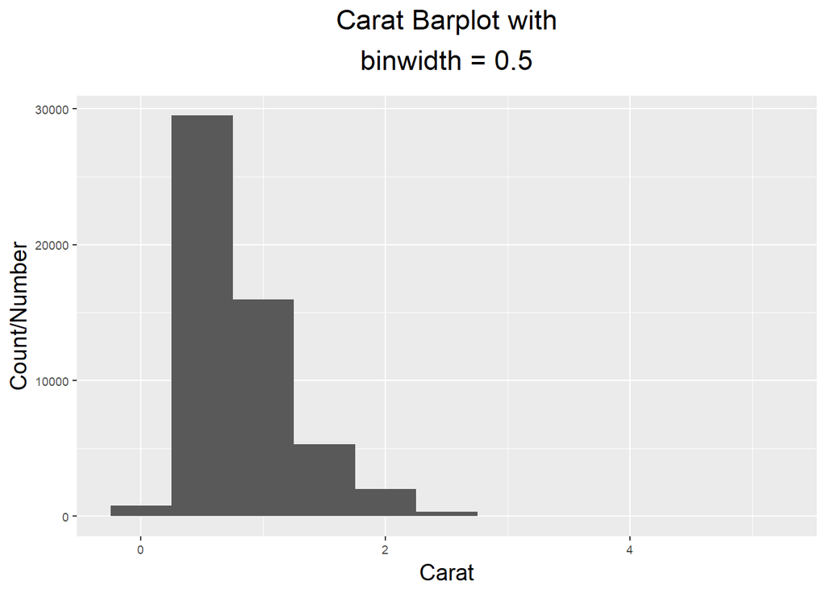

```r
ggplot(diamonds, aes(carat)) +
  geom_histogram(binwidth = 0.5) +
  ggtitle(expression(atop("Carat Barplot with", "binwidth = 0.5"))) +
  xlab("Carat") +
  ylab("Count/Number") +
  theme(plot.title = element_text(hjust = 0.5), title = element_text(size = 14),
        text = element_text(size = 9))
```

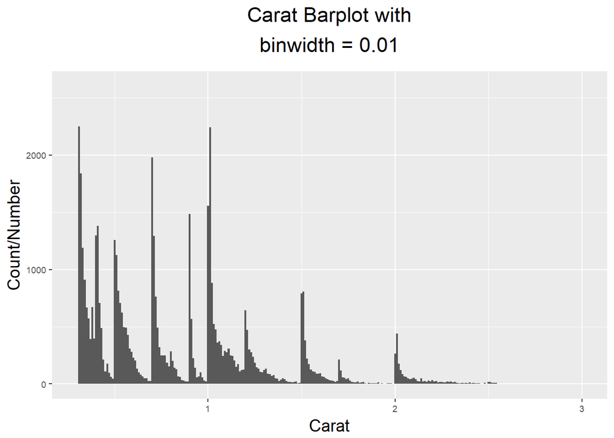

```r
ggplot(diamonds, aes(x = carat)) +
  geom_histogram(binwidth = 0.01) +
  ggtitle(expression(atop("Carat Barplot with", "binwidth = 0.01"))) +
  xlim(0.3, 3) +
  xlab("Carat") +
  ylab("Count/Number") +
  theme(plot.title = element_text(hjust = 0.5), title = element_text(size = 14),
        text = element_text(size = 9))
```

I am not familiar with diamonds industry, but the pattern looks interesting and there must be a reason for this pattern.

*Question 4* Explore the distribution of the price variable in the diamonds data. How does the distribution vary by cut?

To check this::

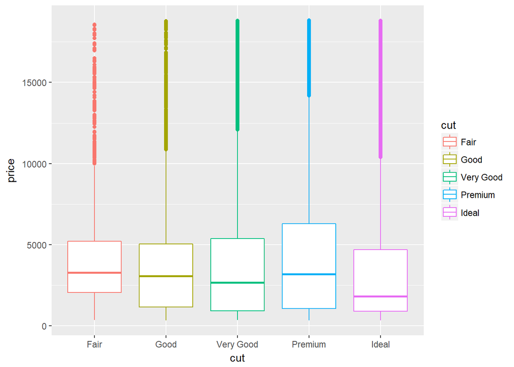

```r
ggplot(diamonds, aes(x = cut, y = price, color = cut)) +
  geom_boxplot()
```

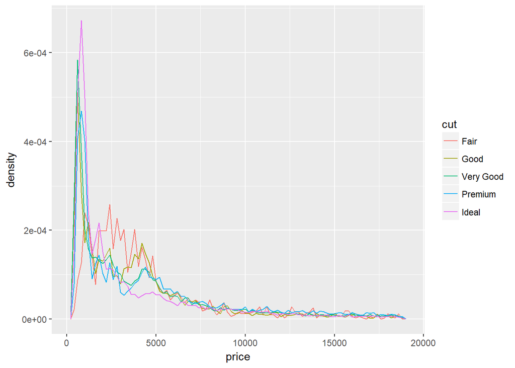

```r
ggplot(diamonds, aes(x = price, y =..density.., color = cut)) +
  geom_freqpoly(binwidth = 200)
```

Fair cut diamonds have higher price than very good cut. One of the reasons could be these fair diamonds are big in terms of their sizes, so people are likely to spend money for the size than for the cut, because not everyone is an expert in diamonds.

*Question 5* You now know (at least) three ways to compare the distributions of subgroups: geom violin(), geom freqpoly() and the colour aesthetic, or geom histogram() and facetting. What are the strengths and weaknesses of each approach? What other approaches could you try?

The strengths and weaknesses are discussed in the chapter already.

*Question 6* Read the documentation for geom bar().What does the weight aesthetic do? There are two types of bar charts: geom_bar makes the height of the bar proportional to the number of cases in each group (or if the weight aethetic is supplied, the sum of the weights). If you want the heights of the bars to represent values in the data, use geom_col instead. geom_bar uses stat_count by default: it counts the number of cases at each x position. geom_col uses stat_identity: it leaves the data as is.

*END OF CHAPTER 2 EXERCISES*